# Power analysis

Miriam Schulz

2024-12-13

```r
library(lme4)
library(lmerTest)
library(designr)
library(dplyr)
library(ggplot2)
rm(list = ls())
```

# 1 About

Power analysis for the Cloze Prediction & Production experiment.

## 1.1 Design

A 2 x 2 target manipulation design.

Dependent variable: RTs.

Predictor variables

- Expectancy (high vs. low; numeric Cloze probability will be used as the predictor)
- Task (Cloze production vs. reading comprehension only)

# 2 Power analysis

## 2.1 Functions

### 2.1.1 Data simulation function

To simulate many data sets, write a function that generates a new data frame for a given number of items and subjects:

```r
generate_dataframe <- function(n_subj, n_items) {

  # Generate Latin Square design
  design <-
    fixed.factor("Expectancy", levels=c("High", "Low")) +
    fixed.factor("Task", levels=c("Production", "Comprehension")) +
    random.factor("Item", instances=n_items/4) +
    random.factor("Subj", instances=n_subj/4) +
    random.factor(c("Subj", "Item"), groups=c("Expectancy", "Task"))
  dat <- dplyr::arrange(design.codes(design), Subj, Item)

  # Convert to factor
  dat <- dat %>% mutate(across(all_of(colnames(dat)), ~ as.factor(.)))

  # Add Cloze Probability
  dat <- merge(dat, stim, by=c("Item", "Expectancy"))
  dat$Item <- as.factor(dat$Item)

  # Set contrasts
  contrasts(dat$Expectancy) <- c(-0.5, 0.5)
  contrasts(dat$Task) <- c(-0.5, 0.5)

  return(dat)
}
```

### 2.1.2 Power analysis function

Define a function for the power analysis:

```r
power_analysis <- function(dat,
                           mean_rt,
                           cloze_fixed, task_fixed, interaction_fixed,
                           n_subj, n_items,
                           verbose=FALSE,
                           vocal=FALSE) {

  if (vocal == TRUE) {
      system(paste0("say Total number of simulations: ", length(n_subj)))
  }

  for (s in 1:length(n_subj)) {

    cat("SIMULATION NO. ", s, "/", length(n_subj), sep=" ", end="\n")

    for (i in 1:length(n_items)) {

      dat <- generate_dataframe(n_subj[s], n_items[i])
      nsj <- length(unique(dat$Subj))
      nit <- length(unique(dat$Item))

      if (verbose == TRUE) {
        cat("   Unique subjects:", length(unique(dat$Subj)), sep=" ", end="\n")
        cat("   Unique items:   ", length(unique(dat$Item)), sep=" ", end="\n")
      }

      for (e in 1:length(cloze_fixed)) {
        cloze <- cloze_fixed[e]

        for (t in 1:length(task_fixed)) {
          task <- task_fixed[t]

          for (ia in 1:length(interaction_fixed)) {
            interact <- interaction_fixed[ia]

            if (verbose == TRUE) {
              cat("      Cloze:      ", cloze, sep=" ", end="\n")
              cat("      Task:       ", task, sep=" ", end="\n")
              cat("      Interaction:", interact, sep=" ", end="\n")
            }

            fix <- c(mean_rt, cloze, task, interact)

            # For each iteration, run several simulations for more stable results
            for (j in 1:10) {

              # Simulate the response variable
              dat$RTsim <- simLMM(
                form = ~ 1 + ClozeProb * Task +
                  (1 + ClozeProb + Task | Subj) +
                  (1 + ClozeProb + Task | Item),
                data   = dat,
                Fixef  = fix,
                VC_sd  = list(sd_Subj, sd_Item, sd_Res),
                CP     = 0.3,
                empirical = FALSE,
                verbose = FALSE
              )

              #ww <- ""  # init

              # Run an LMM
              suppressMessages(
                suppressWarnings(LMM <- withCallingHandlers({
                  lmer(
                    RTsim ~ 1 + ClozeProb * Task +
                      # (1 + ClozeProb + Task || Subj) +
                      # (1 + ClozeProb + Task || Item),
                      (1 | Subj) +
                      (1 | Item),
                    data = dat,
                    REML = FALSE,
                    control = lmerControl(calc.derivs = FALSE)
                  )
                }#,
                #warning = function(w) { ww <<- w$message }
              )))

              # Append the LMM estimates to the COF data frame
              LMMcof <- coef(summary(LMM))
              COF <- rbind(
                COF,
                c(nsj, nit, cloze, task, interact,
                  LMMcof["ClozeProb", ], LMMcof["Task1", ],
                  LMMcof["ClozeProb:Task1", ],
                  isSingular(LMM))
              )
              #warn[s] <- ww
            }
          }
        }
      }
    }
    # Progress report (for knitting in R markdown)
    if (vocal == TRUE) {
      system(paste0("say Finished simulation number ", s))
    } else {
      beepr::beep()  # beep once the current batch of subjects is finished
    }
  }
  #COF$warning <- warn
  return(COF)
}
```

## 2.2 Run power analysis

### 2.2.1 Set parameters

Set the fixed and random effects, and initialize:

```r
# Define a mean RT (intercept)
mean_rt <- 365  # intercept

# Define fixed effects for Expectancy and Task (vectors of same length)
# and their interaction.
# Note that these vectorsmust be the SAME length, but one can vary
# which fixed effect to test by keeping the values in the vectors for the other
# effects constant, e.g., task_fixed <- c(5, 5, 5).
cloze_fixed <- c(2.5, 5, 7.5)  # simulation values for expectancy
task_fixed <- c(50, 100)  # simulation values for task
interaction_fixed <- c(2.5, 5, 7.5)  # simulation values for cloze:task interaction

# Define random effects and variance
sd_Subj <- c(30, 20, 100) # by-subj intercept, by-subj slope for cloze, by-subj slope for task
sd_Item <- c(30, 20, 75)  # by-item intercept, by-item slope for cloze, by-item slope for task
sd_Res  <- 50  # residual variance
```

Define vectors for the number of subjects and items to simulate:

```r
n_subj <- seq(8, 80, 8)
n_items <- seq(64, 80, 8)
```

Read in the stimuli file to extract the Cloze probabilities to be used as predictor:

```r
stim <- read.csv("stim_exp_preprocessed.csv", header = TRUE)
stim$ItemNum <- as.numeric(stim$ItemNum)
stim <- stim %>%
  select(ItemNum, ExpCondition, ClozeProb) %>%
  filter(ItemNum <= 80) %>%
  dplyr::rename(Expectancy = ExpCondition, Item = ItemNum) %>%
  mutate(Item = sprintf("Item%02d", Item))
stim$ClozeProb <- scale(as.numeric(stim$ClozeProb))
```

### 2.2.2 Run

Run power analysis and format power analysis data frame:

```r
set.seed(42)
COF <- data.frame()
#warn <- c()
COF <- power_analysis(dat,
                      mean_rt,
                      cloze_fixed, task_fixed, interaction_fixed,
                      n_subj, n_items,
                      verbose = FALSE,
                      vocal = TRUE)
#warn <- power_output[2]

# Results for LMMs
names(COF) <- c("nsj", "nit", "cloze", "task", "interact",
                "ClozeProb", "SE1", "df1", "t1", "p1",
                "Task", "SE2", "df2", "t2", "p2",
                "Interaction", "SE3", "df3", "t3", "p3",
                "singular")
#COF$warning <- warn
#COF$noWarning <- warn==""
COF$sign1   <- as.numeric(COF$p1 < .05) # determine significant results; one-tailed
COF$sign2   <- as.numeric(COF$p2 < .05) # Significant results for Task
COF$sign3   <- as.numeric(COF$p3 < .05) # Significant results for Task

# COF$nsjF   <- gtools::quantcut(COF$nsj, q=seq(0,1,length=10))
# COF$nsjFL  <- plyr::ddply(COF,"nsjF", transform,nsjFL=mean(nsj))$nsjFL

save(COF, file="power.rda")
```

## 2.3 Plot results

```r
load(file="power.rda")
```

Generate some subsetted data frames for plotting:

```r
# Extract only maximal fixed effects
COF_large_effects <- COF %>%
  filter(cloze == max(cloze)) %>%
  filter(task == max(task)) %>%
  filter(interact == max(interact))

# Extract only minimal fixed effects
COF_small_effects <- COF %>%
  filter(cloze == min(cloze)) %>%
  filter(task == min(task)) %>%
  filter(interact == min(interact))
```

### 2.3.1 Power by N of subjects & effect size

```r
power_plot_effects <- function(dat, sign, predictor, plottitle) {
  p <- ggplot(data=dat) +
    geom_smooth(aes(x=nsj, y=eval(parse(text = sign)),
                    color=factor(eval(parse(text = predictor))),
                    fill=factor(eval(parse(text = predictor)))),
                method="loess", se=TRUE)+
    geom_point(   stat="summary", aes(x=nsj, y=eval(parse(text = sign)),
                                      colour=factor(eval(parse(text = predictor))))) +
    geom_errorbar(stat="summary", aes(x=nsj, y=eval(parse(text = sign)),
                                      colour=factor(eval(parse(text = predictor))))) +
    geom_line(    stat="summary", aes(x=nsj, y=eval(parse(text = sign)),
                                      colour=factor(eval(parse(text = predictor))))) +
    geom_hline(yintercept = 0.8, color = "red", linetype = "dashed") +
    geom_hline(yintercept = 1, color = "darkgreen", linetype = "solid") +
    ggtitle(plottitle) +
    xlab("N subjects") +
    ylab("Power") +
    labs(color = "Effect size") +
    theme_minimal() +
    guides(fill = "none")
  return(p)
}

effects_plots <- function(dat) {

  # Extract maximal y axis range to make the two plots comparable side by side
  y_range <- range(c(dat$sign1, dat$sign2, dat$sign3), na.rm = TRUE)

  p1 <- power_plot_effects(dat, "sign1", "cloze", "Power for Cloze Probability")
  p2 <- power_plot_effects(dat, "sign2", "task", "Power for Task")
  p3 <- power_plot_effects(dat, "sign3", "interact", "Power for the Interaction")

  p1 <- p1 + coord_cartesian(ylim = y_range)
  p2 <- p2 + coord_cartesian(ylim = y_range)
  p3 <- p3 + coord_cartesian(ylim = y_range)

  suppressMessages({
    p <- gridExtra::grid.arrange(p1, p2, p3, nrow = 1)
    p
  })

  return(p)
}
```

Plot for the maximal number of items:

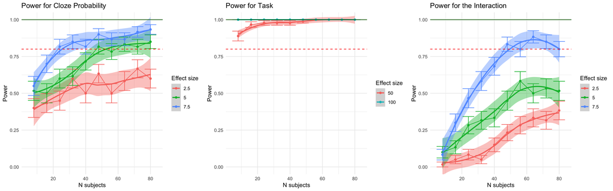

```r
COF_max_items <- filter(COF, nit == max(nit))
p <- effects_plots(COF_max_items)
```

```r
ggsave("./plots/power_by_effectsize_maxitems.png", plot = p,
       width=14, height=5, dpi=320)
```

Plot for the minimal number of items:

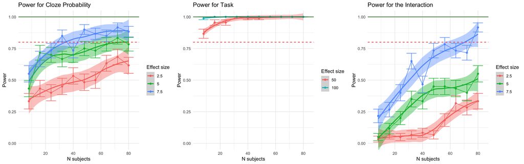

```r
COF_min_items <- filter(COF, nit == min(nit))
p <- effects_plots(COF_min_items)
```

```r
ggsave("./plots/power_by_effectsize_minitems.png", plot = p,
       width=14, height=5, dpi=320)
```

### 2.3.2 Power by N of subjects & N of items

```r
power_plot_items <- function(dat, sign, predictor, plottitle) {
  p <- ggplot(data=dat) +
    geom_smooth(aes(x=nsj, y=eval(parse(text = sign)),
                    color=factor(nit),
                    fill=factor(nit)),
                method="loess", se=FALSE)+
    geom_point(   stat="summary", aes(x=nsj, y=eval(parse(text = sign)),
                                      colour=factor(nit))) +
    geom_errorbar(stat="summary", aes(x=nsj, y=eval(parse(text = sign)),
                                      colour=factor(nit))) +
    geom_line(    stat="summary", aes(x=nsj, y=eval(parse(text = sign)),
                                      colour=factor(nit))) +
    geom_hline(yintercept = 0.8, color = "red", linetype = "dashed") +
    geom_hline(yintercept = 1, color = "darkgreen", linetype = "solid") +
    ggtitle(plottitle) +
    xlab("N subjects") +
    ylab("Power") +
    labs(color = "N items") +
    theme_minimal() +
    guides(fill = "none")
  return(p)
}

items_plots <- function(dat) {

  # Extract maximal y axis range to make the two plots comparable side by side
  y_range <- range(c(dat$sign1, dat$sign2, dat$sign3), na.rm = TRUE)

  p1 <- power_plot_items(dat, "sign1", "cloze", "Power for Cloze Probability")
  p2 <- power_plot_items(dat, "sign2", "task", "Power for Task")
  p3 <- power_plot_items(dat, "sign3", "interact", "Power for the Interaction")

  p1 <- p1 + coord_cartesian(ylim = y_range)
  p2 <- p2 + coord_cartesian(ylim = y_range)
  p3 <- p3 + coord_cartesian(ylim = y_range)

  suppressMessages({
    gridExtra::grid.arrange(p1, p2, p3, nrow = 1)
  })
}
```

Plot for the maximal effects:

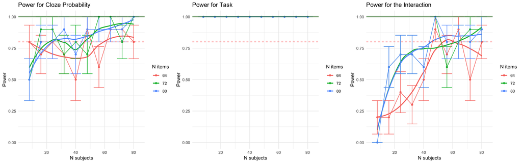

```r
p <- items_plots(COF_large_effects)
```

```r
ggsave("./plots/power_by_items_maxeffects.png", plot = p,
       width=14, height=5, dpi=320)
```

Plot for the smallest effects:

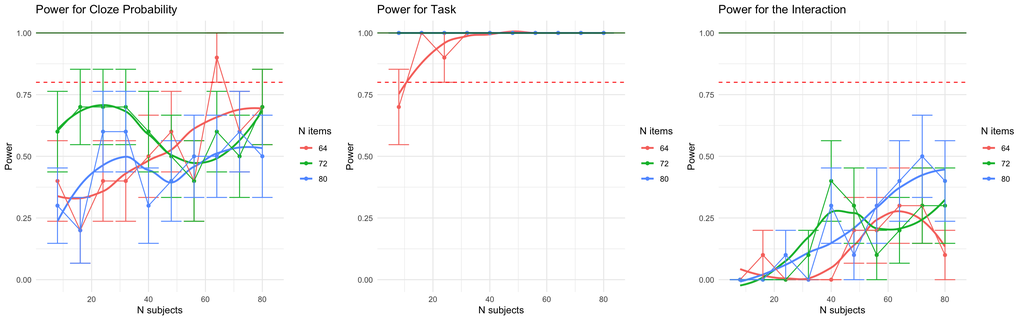

```r
p <- items_plots(COF_small_effects)
```

```r
ggsave("./plots/power_by_items_mineffects.png", plot = p,
       width=14, height=5, dpi=320)
```

## 2.4 N subjects needed to reach 80% power

Determine the number of subjects needed for each effect to reach a power of 80%:

```r
power_threshold <- function(effect_name, effect_vector, sign) {

  print(toupper(effect_name))

  for (i in 1:length(effect_vector)) {
    current <- effect_vector[i]
    COF_current <- COF %>%
      filter(eval(parse(text=effect_name))==current) %>%
      filter(nit == max(nit))

    m0 <- loess(eval(parse(text=sign)) ~ nsj, data=COF_current)
    COF_current$pred <- predict(m0)
    idx <- COF_current$pred>0.8
    min_effect <- ifelse(length(COF_current$nsj[idx]) > 0,
                         min(COF_current$nsj[idx]), FALSE)

    cat("Effect size:", current,
      "-> min required subjects:",
      min_effect, sep=" ", end="\n")
  }
}
```

```r
print("Minimum of required subject to reach >80 power for each effect size (for the maximum number of items):")
```

```
## [1] "Minimum of required subject to reach >80 power for each effect size (for the maximum number of items):"
```

```r
power_threshold("cloze", cloze_fixed, "sign1")
```

```
## [1] "CLOZE"
## Effect size: 2.5 -> min required subjects: FALSE
## Effect size: 5 -> min required subjects: 56
## Effect size: 7.5 -> min required subjects: 32
```

```r
power_threshold("task", task_fixed, "sign2")
```

```
## [1] "TASK"
## Effect size: 50 -> min required subjects: 8
## Effect size: 100 -> min required subjects: 8
```

```r
power_threshold("interact", interaction_fixed, "sign3")
```

```
## [1] "INTERACT"
## Effect size: 2.5 -> min required subjects: FALSE
## Effect size: 5 -> min required subjects: FALSE
## Effect size: 7.5 -> min required subjects: 56
```

Finish sound (play a different sound when finished, to indicate that knitting is done for the Rmd file).

```r
beepr::beep(5)
```